# Results_Exercise_02

## Simulating the discrete-time logistic

### Problem 1

Plot the logistic growth model at r = 1.95, 2.05, 2.5, and 2.8 Describe the trajectory observed in each case.

Iterative simulation

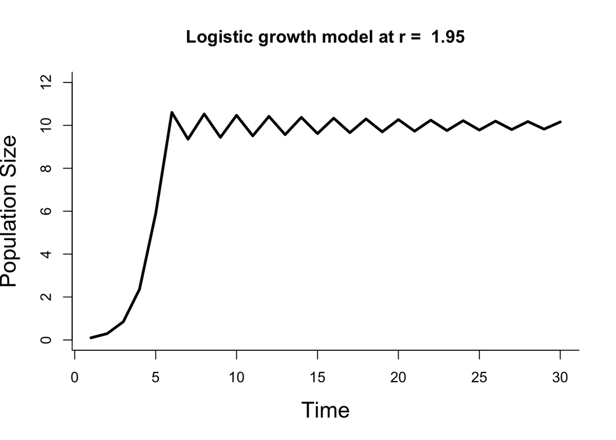

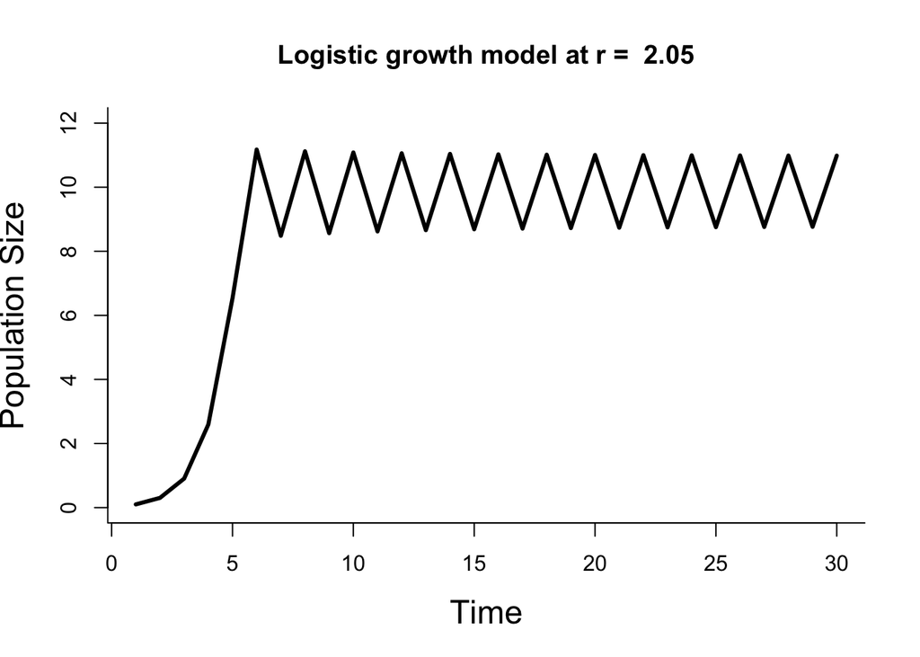

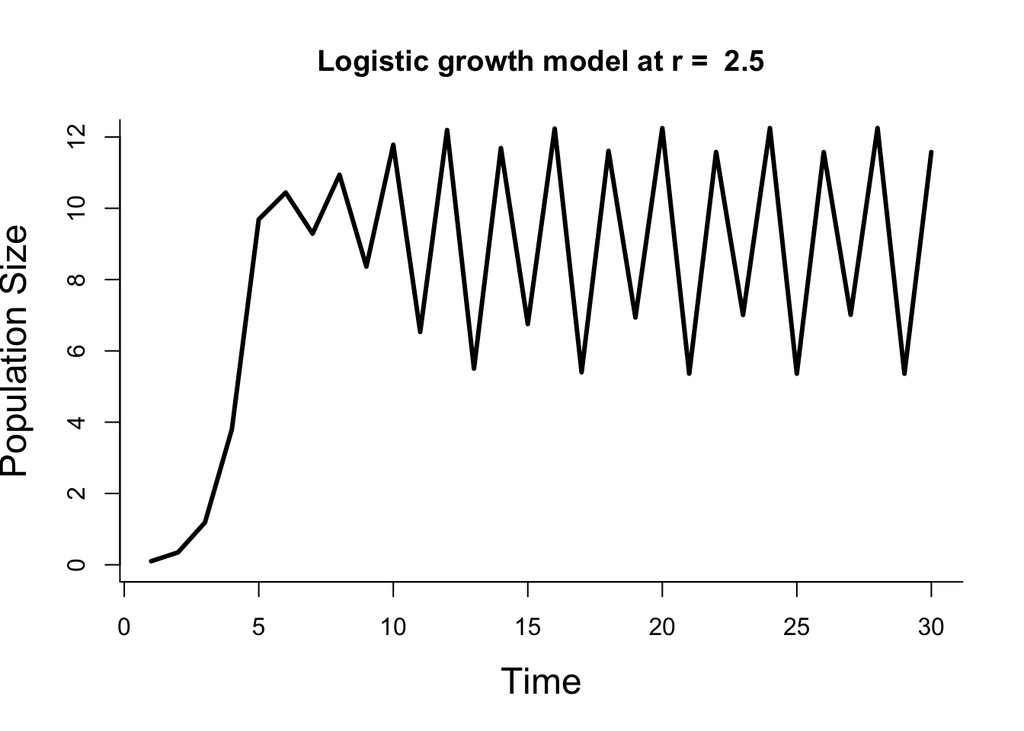

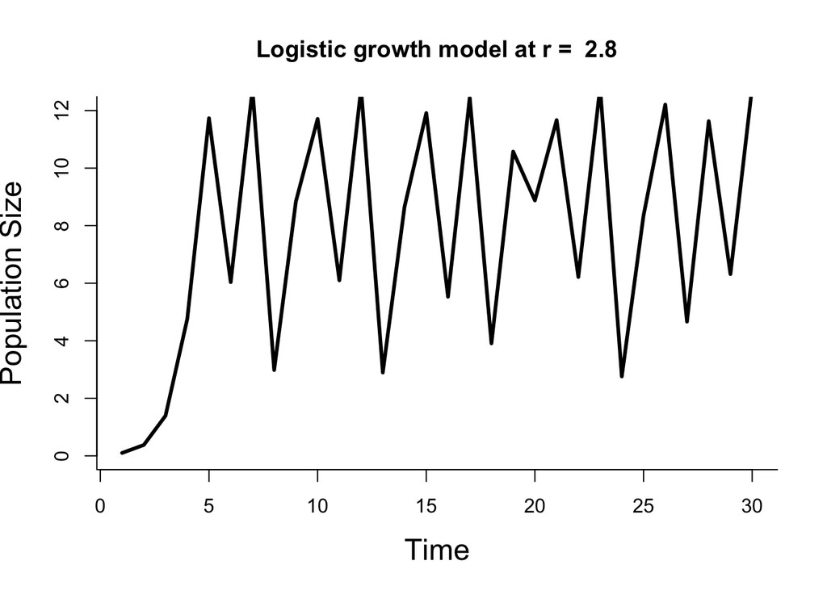

```r
n = rep(n0,NT)    ## vector to store results
rvals <- c(1.95, 2.05, 2.5, 2.8)
for (i in 1:length(rvals)){
  r <- rvals[i]
  for(t in 2:NT){
    n[t] = n[t-1] + r*n[t-1]*(1-n[t-1]/K)
  }
  plot(time,n,ylim=c(0,12),lwd=3,type='l',
       bty='l',cex.lab=1.5,
       xlab="Time",ylab="Population Size",
       main = paste("Logistic growth model at r = ",r))
}
```

### Problem 2

Choose another probability distribution and generate graphs of the probability density function, the cumulative distribution function, the quantile function, and a histogram of samples from that distribution.

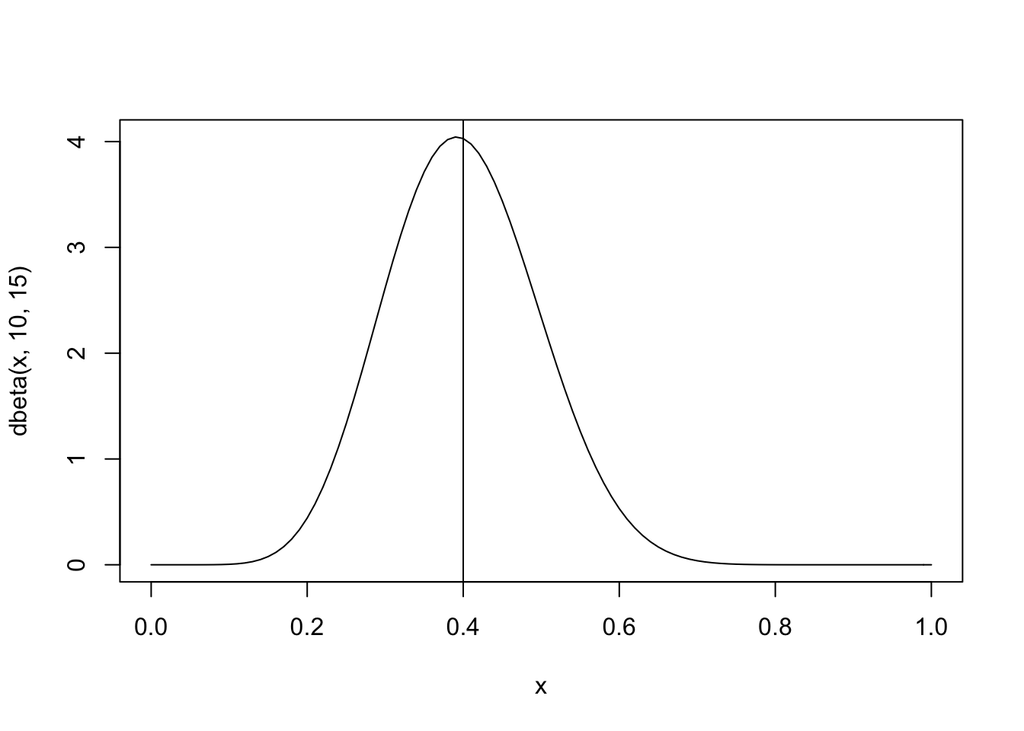

```r
# probability distribution function
x = seq(0,1,by=0.01)
plot(x,dbeta(x, 10, 15),type='l')       ## that’s a lowercase “L” for “line”
abline(v=(10/(10+15)))                      # mean of beta distribution is a/(a+b)
```

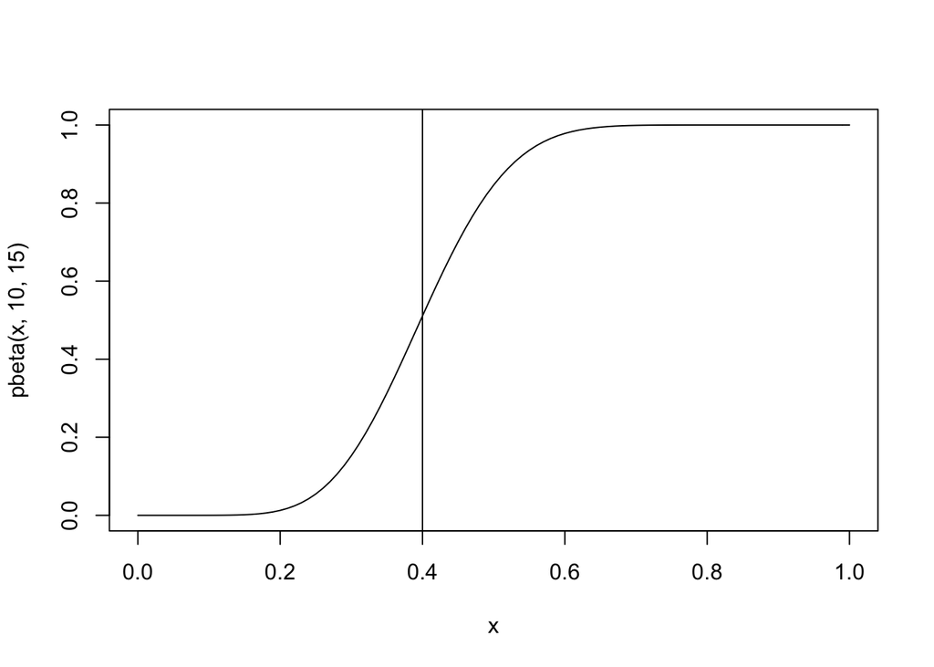

```r
# cumulative distribution function
plot(x,pbeta(x,10,15),type='l')
abline(v=(10/(10+15)))
```

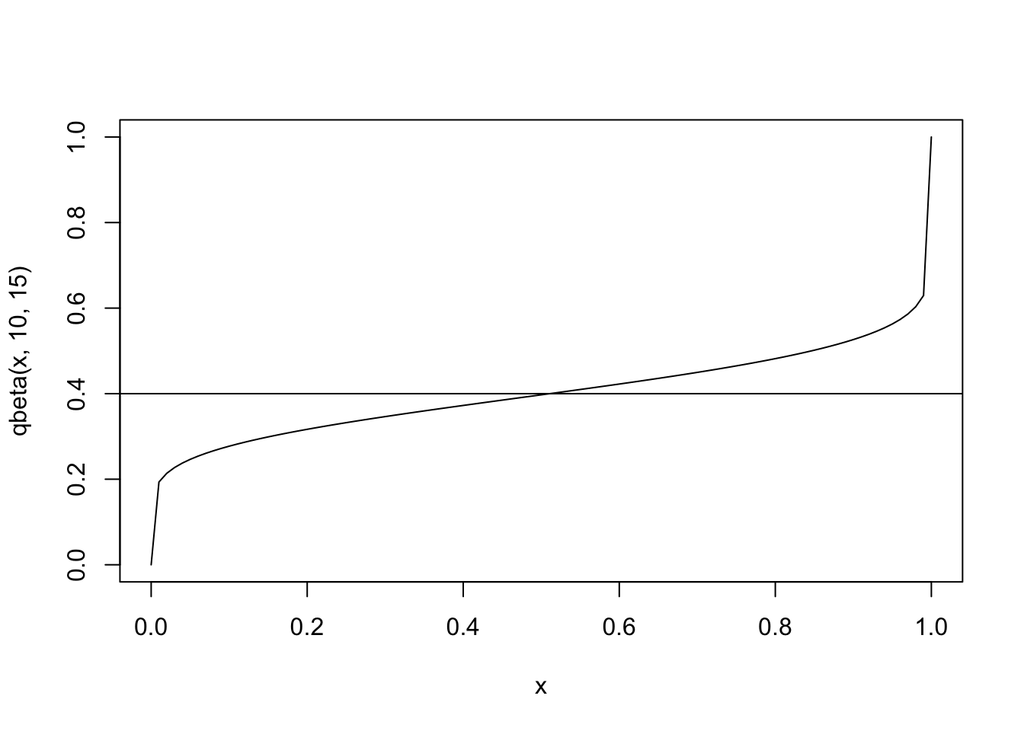

```r
# quantile function
plot(x,qbeta(x,10,15),type='l')
abline(h=(10/(10+15)))
```

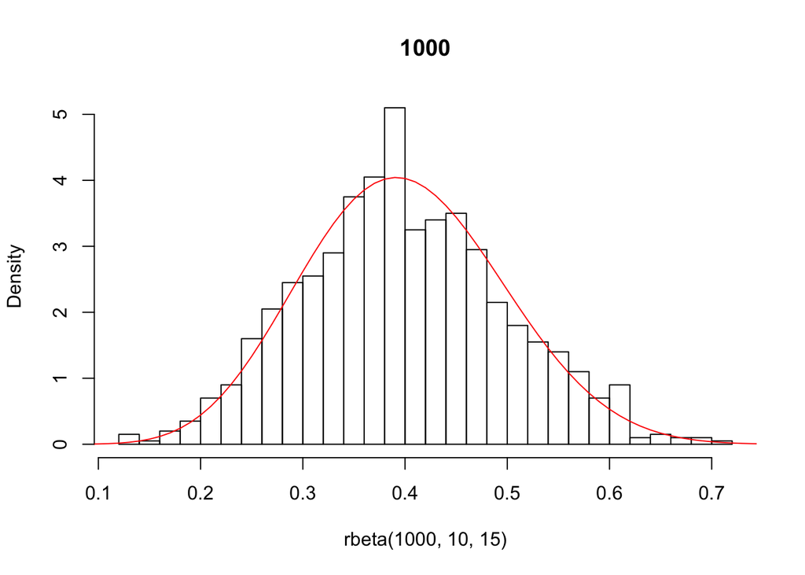

```r
# histogram of 1000 samples
hist(rbeta(1000,10,15),main=1000,probability=TRUE,breaks=40)
lines(x,dbeta(x,10,15),col=2)
```

### Problem 3

Numerically transform a lognormal(meanlog=0,sdlog=0.5) through sin(x) using Monte Carlo simulation. Include histograms of the original and transformed distributions. Report the mean, median, and 95% CI for both distributions and indicate these values on the histograms.

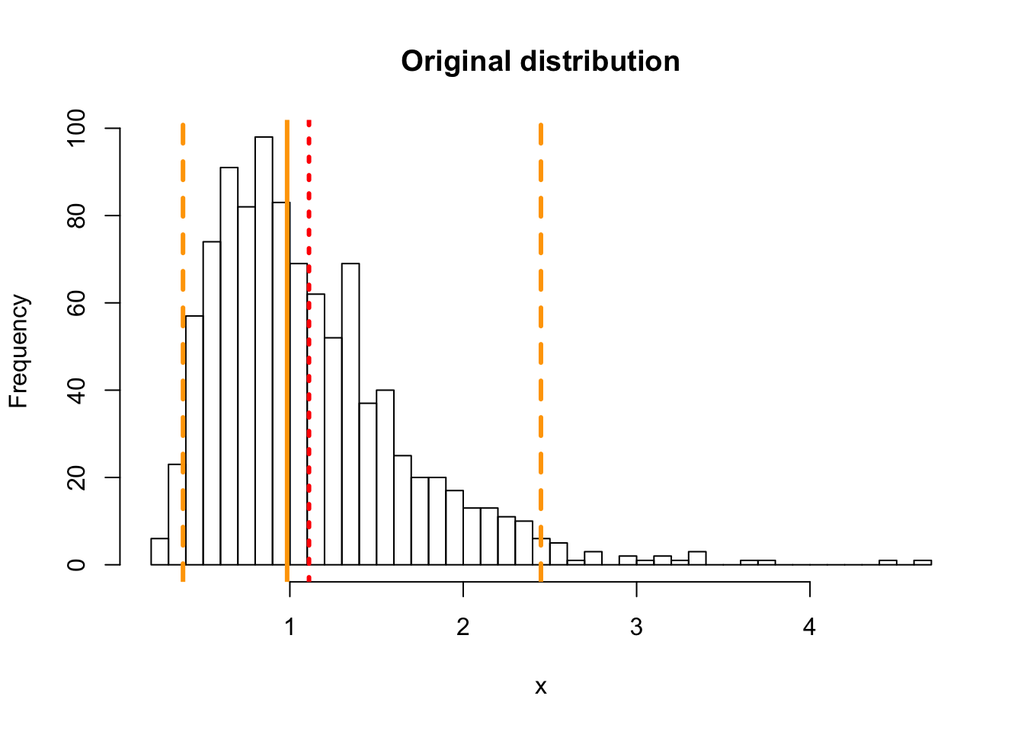

```r
x = rlnorm(1000, meanlog=0,sdlog=0.5)
y = sin(x)

hist(x,main="Original distribution",breaks=40)
abline(v=quantile(x,c(0.025,0.5,0.975)),lty=c(2,1,2),lwd=3,col="orange")
abline(v=mean(x),col="red",lwd=3,lty=3)
```

```r
paste0("Mean = ", mean(x))
```

```
## [1] "Mean = 1.11041016460175"
```

```r
paste0("Median = ", median(x))
```

```
## [1] "Median = 0.984268934091665"
```

```r
paste0("CI = ", quantile(x,c(0.025,0.975)))
```

```
## [1] "CI = 0.383634386949153" "CI = 2.44810314337838"
```

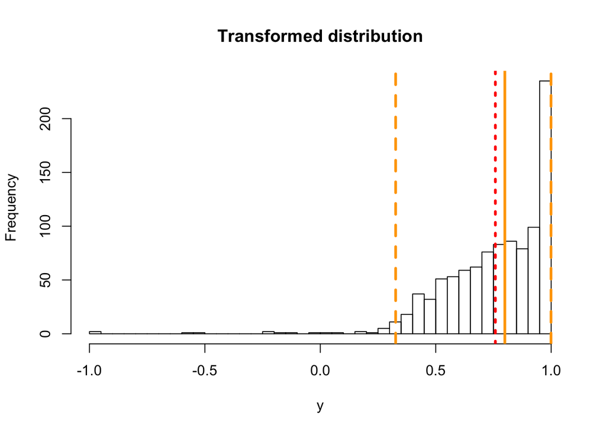

```r
hist(y,main="Transformed distribution",breaks=40)
abline(v=quantile(y,c(0.025,0.5,0.975)),lty=c(2,1,2),lwd=3,col="orange")
abline(v=mean(y),col="red",lwd=3,lty=3)
```

```r
paste0("Mean = ", mean(y))
```

```
## [1] "Mean = 0.758234386129869"
```

```r
paste0("Median = ", median(y))
```

```
## [1] "Median = 0.799277704070421"
```

```r
paste0("CI = ", quantile(y,c(0.025,0.975)))
```

```
## [1] "CI = 0.326300639389561" "CI = 0.999324258181621"
```

### Monte Carlo simulation

```r
r = 2.1
r.sd = 0.2     ## standard deviation on r
K.sd = 1.0     ## standard deviation on K
NE = 1000      ## Ensemble size

n = matrix(n0,NE,NT)   # storage for all simulations
rE = rnorm(NE,r,r.sd)  # sample of r
KE = rnorm(NE,K,K.sd)  # sample of K
for(i in 1:NE){        # loop over samples
  for(t in 2:NT){      # for each sample, simulate throught time
    n[i,t] = n[i,t-1] + rE[i]*n[i,t-1]*(1-n[i,t-1]/KE[i])
  }
}

n.stats = apply(n,2,quantile,c(0.025,0.5,0.975))
```

### Problem 4

Plot histograms of the samples of r and K used for the simulation.

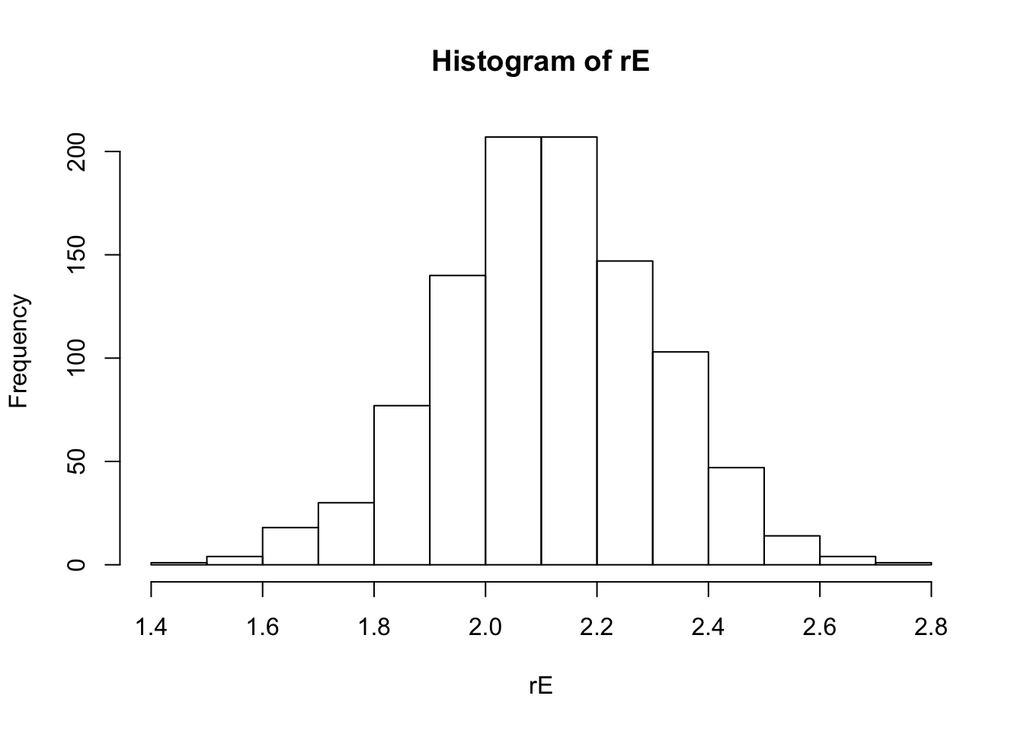

```r
hist(rE)
```

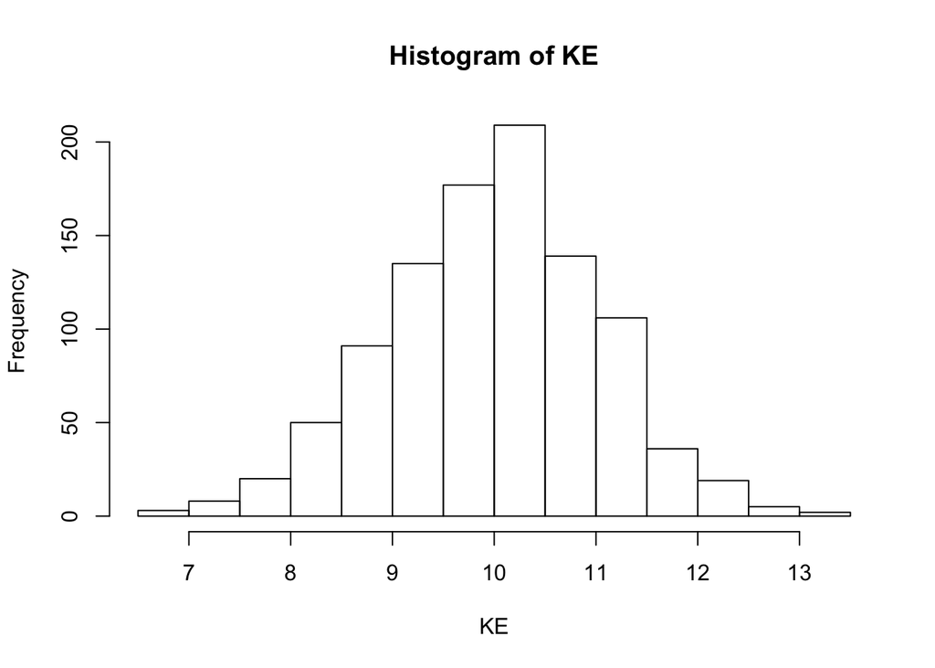

```r
hist(KE)
```

### Problem 5

Plot a sample of 10 different trajectories (through time) from your ensemble (on one graph).

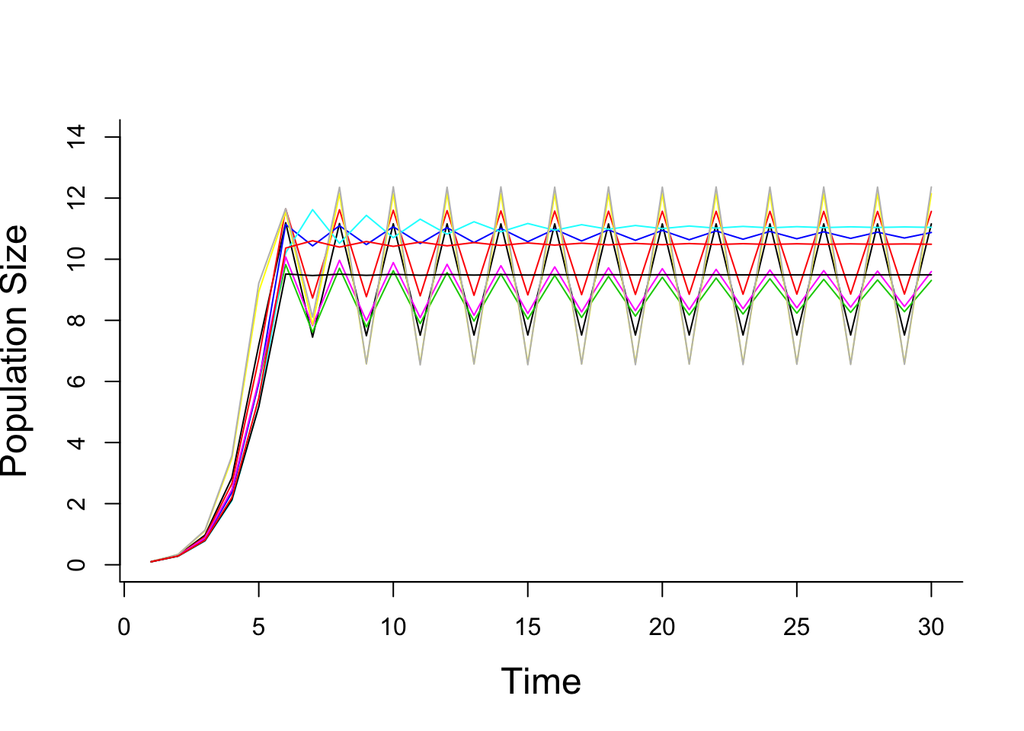

```r
# add first trajectory (first row) to plot
plot(time,n[1,],ylim=c(0,14),type='l',
     bty='l',cex.lab=1.5,
     xlab="Time",ylab="Population Size")

# add next 9 trajectories
for (i in 2:10){
lines(time, n[i,], col=i)
}
```

### Problem 6

Plot a histogram of your population forecast at time = 15.

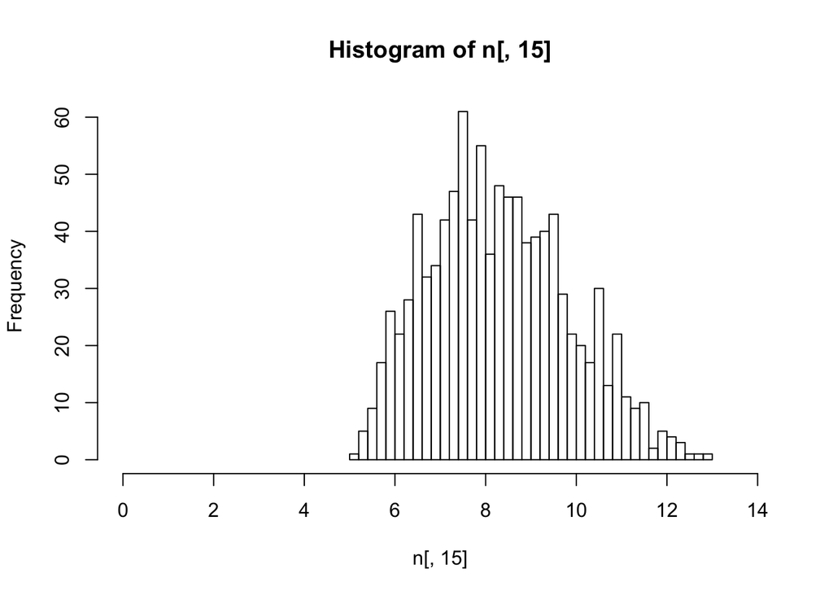

```r
hist(n[,15], breaks=40, xlim=c(0,14))
```